# Introduction to R

Installation Session

# Session Overview

1. What is R?
2. Installing R
3. What is RStudio?
4. Installing RStudio

# What is R?

## What is R?

**R**

- is an open-source statistical programming language.
- available for most operating systems
- helps users analyze, visualize, and model data—from simple summaries to complex data analysis
- is extremely popular in statistics and data science, see [this article](http://r4stats.com/articles/popularity/)
- includes thousands of packages (add-ons) that can be used for specialized tasks without a deep understanding of the language and programming skills
- allows for extensive programming, making it also suitable for advanced or case-specific applications of statistical methods

The combination of the latter two aspects sets **R** apart and makes it useful for everything ranging from standard ‘basic’ statistical analysis to the development of new methods.

The homepage of **R** is www.r-project.org from which you can install **R** and access manuals that provide detailed information about installing and using **R**.

# Installing R

## R Installation

To install **R**, go to the Comprehensive R Archive Network [CRAN](https://cran.r-project.org/). At the time of writing, it looks as follows:

[figure not shown]

## R Installation on Windows

To download, for instance, **R** for Windows, you arrive at the following page:

[figure not shown]

## R Installation on Windows

[figure not shown]

## R Installation on Windows

Start the download process:

[figure not shown]

## R Installation on Windows

Continue the download process:

[figure not shown]

## R Installation on Windows

Download completed:

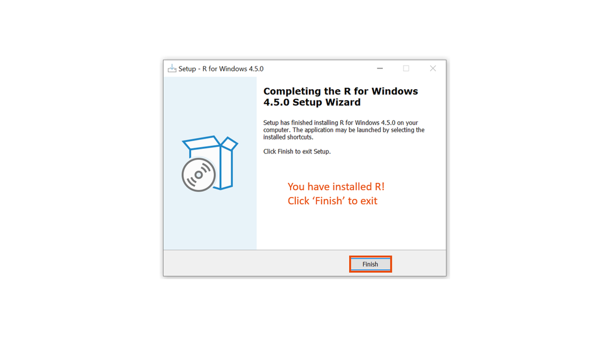

## R Installation on Mac

Choose the right version for your Mac:

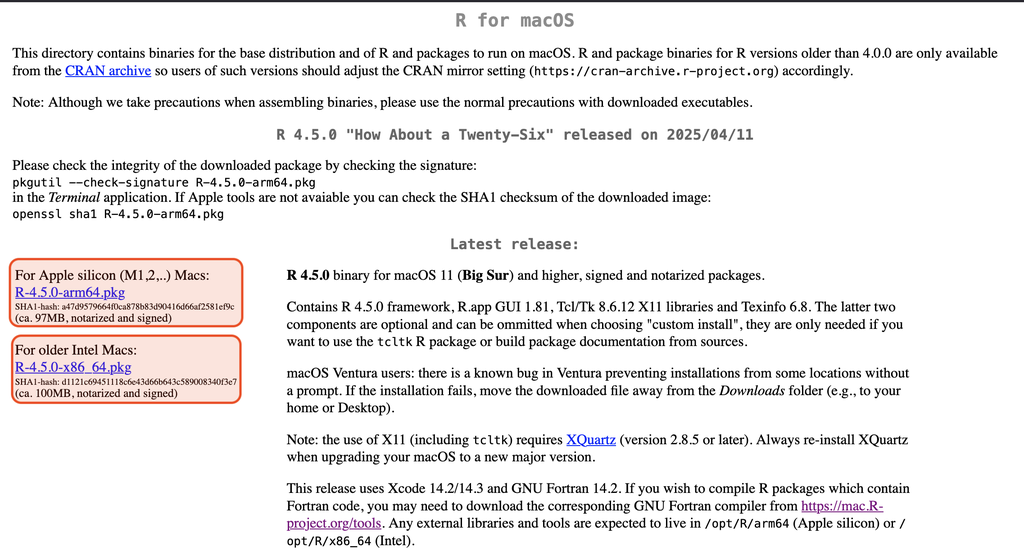

## R Installation on Mac

Download the installation file and open it:

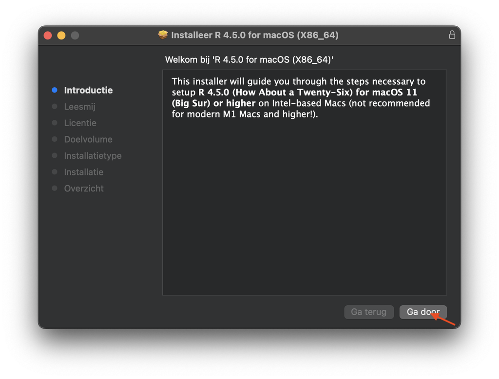

## R Installation on Mac

Simply click continue everywhere, the default installation is fine.

- When asked, enter your password and accept the license agreement.

[figure not shown]

# What is RStudio?

## What is RStudio?

**RStudio**

- is an Integrated Development Environment (IDE) for **R**
- is a user-friendly interface for writing and running **R** code
- makes it easier to write code, analyze data, create visuals, access documentation and manage projects

Its homepage is https://posit.co/download/rstudio-desktop/

# Installing RStudio

## RStudio Installation on Windows

To download **RStudio**, go to its [download](https://posit.co/download/rstudio-desktop/) page. At the time of writing, it looks as follows:

[figure not shown]

## RStudio Installation on Windows

Start the download process:

[figure not shown]

## RStudio Installation on Mac

If you open the (same) [download](https://posit.co/download/rstudio-desktop/) page on Mac, you directly see the download button for Mac:

[figure not shown]

## RStudio Installation on Mac

Open the downloaded RStudio dmg file, and drag the RStudio icon into the applications folder:

[figure not shown]